# Practical Machine Learning

Pooja

July 12, 2016

### 1.Overview:

This document is the final report of the Peer Assessment project from Coursera’s course Practical Machine Learning, as part of the Specialization in Data Science. It was built up in RStudio, using its knitr functions, meant to be published in html format. This analysis meant to be the basis for the course quiz and a prediction assignment writeup. The main goal of the project is to predict the manner in which 6 participants performed some exercise as described below. This is the “classe” variable in the training set. The machine learning algorithm described here is applied to the 20 test cases available in the test data and the predictions are submitted in appropriate format to the Course Project Prediction Quiz for automated grading.

A short description of the datasets content from the authors’ website: “Six young health participants were asked to perform one set of 10 repetitions of the Unilateral Dumbbell Biceps Curl in five different fashions: exactly according to the specification (Class A), throwing the elbows to the front (Class B), lifting the dumbbell only halfway (Class C), lowering the dumbbell only halfway (Class D) and throwing the hips to the front (Class E).

Class A corresponds to the specified execution of the exercise, while the other 4 classes correspond to common mistakes. Participants were supervised by an experienced weight lifter to make sure the execution complied to the manner they were supposed to simulate. The exercises were performed by six male participants aged between 20-28 years, with little weight lifting experience. We made sure that all participants could easily simulate the mistakes in a safe and controlled manner by using a relatively light dumbbell (1.25kg)."

### 3.Loading and cleaning Data

1. Dataset Overview The training data for this project are available here:

https://d396qusza40orc.cloudfront.net/predmachlearn/pml-training.csv

The test data are available here:

https://d396qusza40orc.cloudfront.net/predmachlearn/pml-testing.csv

2. Environment Preparation We first upload the R libraries that are necessary for the complete analysis.

```r
library(knitr)
library(caret)
```

```r
library(rpart)
library(rpart.plot)
library(rattle)
library(randomForest)
library(corrplot)
knitr::opts_chunk$set(cache=TRUE)
```

### 4 Getting the data

```r
training<- read.csv(url("http://d396qusza40orc.cloudfront.net/predmachlearn/pml-training.csv"),na.strings =c( "NA","","#DIV/0!"))
testing<- read.csv(url("http://d396qusza40orc.cloudfront.net/predmachlearn/pml-testing.csv"),na.strings =c( "NA","","#DIV/0!"))
dim(training)
```

```
## [1] 19622   160
```

```r
dim(testing)
```

```
## [1]  20 160
```

The raw training data has 19622 rows of observations and 158 features (predictors). Column `X` is unusable row number. While the testing data has 20 rows and the same 158 features. There is one column of target outcome named `classe`.

### 5 Cleaning the data

```r
featuretrain = grepl("belt|arm|dumbell", names(training))
training1<- training[,featuretrain]
testing1<-  testing[,featuretrain]
```

b.)Some columns were mostly blank. These did not contribute well to the prediction. I chose a feature set that only included complete columns.

```r
##remove columns containing NA's
training2<- training1[,colSums(is.na(training1))==0]
testing2<- testing1[,colSums(is.na(training1))==0]
```

### 6 Preprocessing the data

### Check for features’s variance

It is important that features have maximum variance for maximum uniqueness, so that each feature is as distant as possible (as orthogonal as possible) from the other features.

```r
nzvtrain = nearZeroVar(training2, saveMetrics=TRUE)
nzvtrain
```

```
##                     freqRatio percentUnique zeroVar   nzv
## roll_belt            1.101904     6.7781062   FALSE FALSE
## pitch_belt           1.036082     9.3772296   FALSE FALSE
## yaw_belt             1.058480     9.9734991   FALSE FALSE
## total_accel_belt     1.063160     0.1477933   FALSE FALSE
## gyros_belt_x         1.058651     0.7134849   FALSE FALSE
## gyros_belt_y         1.144000     0.3516461   FALSE FALSE
## gyros_belt_z         1.066214     0.8612782   FALSE FALSE
## accel_belt_x         1.055412     0.8357966   FALSE FALSE
## accel_belt_y         1.113725     0.7287738   FALSE FALSE
## accel_belt_z         1.078767     1.5237998   FALSE FALSE
## magnet_belt_x        1.090141     1.6664968   FALSE FALSE
## magnet_belt_y        1.099688     1.5187035   FALSE FALSE
## magnet_belt_z        1.006369     2.3290184   FALSE FALSE
## roll_arm            52.338462    13.5256345   FALSE FALSE
## pitch_arm           87.256410    15.7323412   FALSE FALSE
## yaw_arm             33.029126    14.6570176   FALSE FALSE
## total_accel_arm      1.024526     0.3363572   FALSE FALSE
## gyros_arm_x          1.015504     3.2769341   FALSE FALSE
## gyros_arm_y          1.454369     1.9162165   FALSE FALSE
## gyros_arm_z          1.110687     1.2638875   FALSE FALSE
## accel_arm_x          1.017341     3.9598410   FALSE FALSE
## accel_arm_y          1.140187     2.7367241   FALSE FALSE
## accel_arm_z          1.128000     4.0362858   FALSE FALSE
## magnet_arm_x         1.000000     6.8239731   FALSE FALSE
## magnet_arm_y         1.056818     4.4439914   FALSE FALSE
## magnet_arm_z         1.036364     6.4468454   FALSE FALSE
## roll_forearm        11.589286    11.0895933   FALSE FALSE
## pitch_forearm       65.983051    14.8557741   FALSE FALSE
## yaw_forearm         15.322835    10.1467740   FALSE FALSE
## total_accel_forearm  1.128928     0.3567424   FALSE FALSE
## gyros_forearm_x      1.059273     1.5187035   FALSE FALSE
## gyros_forearm_y      1.036554     3.7763735   FALSE FALSE
## gyros_forearm_z      1.122917     1.5645704   FALSE FALSE
## accel_forearm_x      1.126437     4.0464784   FALSE FALSE
## accel_forearm_y      1.059406     5.1116094   FALSE FALSE
## accel_forearm_z      1.006250     2.9558659   FALSE FALSE
## magnet_forearm_x     1.012346     7.7667924   FALSE FALSE
## magnet_forearm_y     1.246914     9.5403119   FALSE FALSE
## magnet_forearm_z     1.000000     8.5771073   FALSE FALSE
```

It shows that all features have enough variance.With the cleaning process above, the number of variables for the analysis has been reduced to 39 only.

### 7 Data Partitioning and Prediction Process

The cleaned downloaded data set was subset in order to generate a test set independent from the 20 cases provided set. Partitioning was performed to obtain a 75% training set and a 25% test set.

```r
##Include outcome variable in training set
training2$classe<- training$classe
##partitiond the training dataset in train and test dataset
inTrain<- createDataPartition(training2$classe, p=0.75, list = FALSE)
train<-training2[inTrain,]
test<-training2[-inTrain,]
```

### 8 Correlation Analysis

A correlation among variables is analysed before proceeding to the modeling procedures.

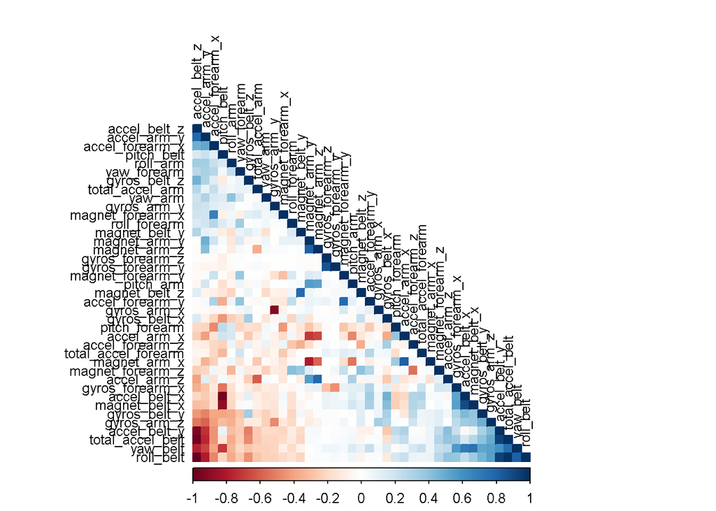

```r
corMatrix <- cor(train[, -40])
corrplot(corMatrix, order = "FPC", method = "color", type = "lower",tl.cex = 0.8, tl.col = rgb(0, 0, 0))
```

The highly correlated variables are shown in dark colors in the graph above. To make an evem more compact analysis, a PCA (Principal Components Analysis) could be performed as pre-processing step to the datasets. Nevertheless, as the correlations are quite few, this step will not be applied for this assignment.

### 9 Prediction Model Building

1. Method: Random Forest

```r
set.seed(12345)
control <- trainControl(method="cv", number=2, verboseIter=FALSE)
Fitrf <- train(classe ~ ., data=train, method="rf",trControl=control)
```

prediction on Test dataset

```r
predrf<-predict(Fitrf, newdata=test)
cmrf<- confusionMatrix(predrf, test$classe)
cmrf
```

```
## Confusion Matrix and Statistics
##
##           Reference
## Prediction    A    B    C    D    E
##          A 1393    2    1    2    1
##          B    1  943    6    1    0
##          C    1    4  836   11    0
##          D    0    0   11  789    0
##          E    0    0    1    1  900
##
## Overall Statistics
##
##                Accuracy : 0.9912
##                  95% CI : (0.9882, 0.9936)
##     No Information Rate : 0.2845
##     P-Value [Acc > NIR] : < 2.2e-16
##
##                   Kappa : 0.9889
##  Mcnemar's Test P-Value : NA
##
## Statistics by Class:
##
##                      Class: A Class: B Class: C Class: D Class: E
## Sensitivity            0.9986   0.9937   0.9778   0.9813   0.9989
## Specificity            0.9983   0.9980   0.9960   0.9973   0.9995
## Pos Pred Value         0.9957   0.9916   0.9812   0.9862   0.9978
## Neg Pred Value         0.9994   0.9985   0.9953   0.9963   0.9998
## Prevalence             0.2845   0.1935   0.1743   0.1639   0.1837
## Detection Rate         0.2841   0.1923   0.1705   0.1609   0.1835
## Detection Prevalence   0.2853   0.1939   0.1737   0.1631   0.1839
## Balanced Accuracy      0.9984   0.9958   0.9869   0.9893   0.9992
```

2. Method: Decision Trees

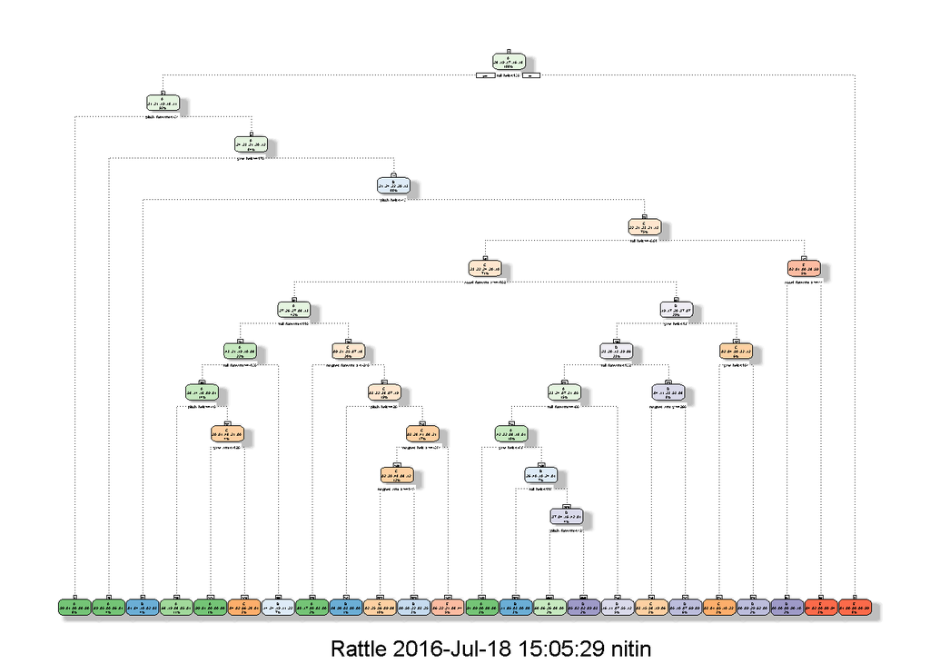

```r
FitTree <- rpart(classe ~ ., data=train, method="class")
fancyRpartPlot(FitTree)
```

prediction on Test dataset

```r
predictTree <- predict(FitTree, newdata=test, type="class")
cmTree <- confusionMatrix(predictTree, test$classe)
cmTree
```

```
## Confusion Matrix and Statistics
##
##           Reference
## Prediction    A    B    C    D    E
##          A 1213  122   60   53    6
##          B   77  555  117   57  119
##          C   34  161  554  131   70
##          D   51   54   69  547   74
##          E   20   57   55   16  632
##
## Overall Statistics
##
##                Accuracy : 0.7139
##                  95% CI : (0.701, 0.7265)
##     No Information Rate : 0.2845
##     P-Value [Acc > NIR] : < 2.2e-16
##
##                   Kappa : 0.6377
##  Mcnemar's Test P-Value : < 2.2e-16
##
## Statistics by Class:
##
##                      Class: A Class: B Class: C Class: D Class: E
## Sensitivity            0.8695   0.5848   0.6480   0.6803   0.7014
## Specificity            0.9313   0.9064   0.9022   0.9395   0.9630
## Pos Pred Value         0.8343   0.6000   0.5832   0.6881   0.8103
## Neg Pred Value         0.9472   0.9010   0.9239   0.9375   0.9348
## Prevalence             0.2845   0.1935   0.1743   0.1639   0.1837
## Detection Rate         0.2473   0.1132   0.1130   0.1115   0.1289
## Detection Prevalence   0.2965   0.1886   0.1937   0.1621   0.1591
## Balanced Accuracy      0.9004   0.7456   0.7751   0.8099   0.8322
```

3. Method: Generalized Boosted Model

```r
controlgbm <- trainControl(method = "cv", number = 2)
FitGBM  <- train(classe ~ ., data=train, method = "gbm", trControl = controlgbm, verbose = FALSE)
```

prediction on Test dataset

```r
predictGBM <- predict(FitGBM, newdata=test)
cmGBM<- confusionMatrix(predictGBM, test$classe)
cmGBM
```

```
## Confusion Matrix and Statistics
##
##           Reference
## Prediction    A    B    C    D    E
##          A 1364   29    0    5    2
##          B   18  864   60    2   18
##          C    5   51  761   40    8
##          D    8    1   29  752   21
##          E    0    4    5    5  852
##
## Overall Statistics
##
##                Accuracy : 0.9366
##                  95% CI : (0.9294, 0.9432)
##     No Information Rate : 0.2845
##     P-Value [Acc > NIR] : < 2.2e-16
##
##                   Kappa : 0.9198
##  Mcnemar's Test P-Value : 0.0003265
##
## Statistics by Class:
##
##                      Class: A Class: B Class: C Class: D Class: E
## Sensitivity            0.9778   0.9104   0.8901   0.9353   0.9456
## Specificity            0.9897   0.9752   0.9743   0.9856   0.9965
## Pos Pred Value         0.9743   0.8981   0.8798   0.9273   0.9838
## Neg Pred Value         0.9912   0.9784   0.9767   0.9873   0.9879
## Prevalence             0.2845   0.1935   0.1743   0.1639   0.1837
## Detection Rate         0.2781   0.1762   0.1552   0.1533   0.1737
## Detection Prevalence   0.2855   0.1962   0.1764   0.1654   0.1766
## Balanced Accuracy      0.9838   0.9428   0.9322   0.9605   0.9711
```

Seeing above results, the Random Forest model will be applied to predict the 20 quiz results (testing dataset) as shown below.

```r
predictTEST <- predict(Fitrf, newdata=testing)
predictTEST
```

```
##  [1] B A B A A E D B A A B C B A E E A B B B
## Levels: A B C D E
```